# Lab 10 - RF, XGBoost

# Learning goals

- Perform classification and regression with tree-based methods in R
- Recognize that tree-based methods are capable of capturing non-linearities by splitting multiple times on the same variables
- Compare the performance of classification trees, bagging, random forests, and boosting for predicting heart disease based on the `heart` data.

# Lab description

For this lab we will be working with simulated data and the `heart` dataset that you can download from [here](https://github.com/JSC370/jsc370-2023/blob/main/data/heart/heart.csv)

### Setup packages

You should install and load `rpart` (trees), `randomForest` (random forest), `gbm` (gradient boosting) and `xgboost` (extreme gradient boosting).

```r
install.packages(c("rpart", "rpart.plot", "randomForest", "gbm", "xgboost"))
```

### Load packages and data

```r
library(tidyverse)
library(rpart)
library(rpart.plot)
library(randomForest)
library(gbm)
library(xgboost)
heart <- read.csv("https://raw.githubusercontent.com/JSC370/jsc370-2023/main/data/heart/heart.csv") |>
  mutate(
    AHD = 1 * (AHD == "Yes"),
    ChestPain = factor(ChestPain),
    Thal = factor(Thal)
  )
head(heart)
```

```
##   Age Sex    ChestPain RestBP Chol Fbs RestECG MaxHR ExAng Oldpeak Slope Ca
## 1  63   1      typical    145  233   1       2   150     0     2.3     3  0
## 2  67   1 asymptomatic    160  286   0       2   108     1     1.5     2  3
## 3  67   1 asymptomatic    120  229   0       2   129     1     2.6     2  2
## 4  37   1   nonanginal    130  250   0       0   187     0     3.5     3  0
## 5  41   0   nontypical    130  204   0       2   172     0     1.4     1  0
## 6  56   1   nontypical    120  236   0       0   178     0     0.8     1  0
##         Thal AHD
## 1      fixed   0
## 2     normal   1
## 3 reversable   1
## 4     normal   0
## 5     normal   0
## 6     normal   0
```

# Questions

## Question 1: Trees with simulated data

- Simulate data from a random uniform distribution [-5,5] and normally distributed errors (s.d = 0.5)
- Create a non-linear relationship y=sin(x)+error
- Split the data into test and training sets (500 points each), plot the data

$$Y_1 = \sin(X_1) + \varepsilon_1$$
$$\varepsilon_1 \sim N(0, 0.5^2)$$
for $i = 1, \dots 1000$.

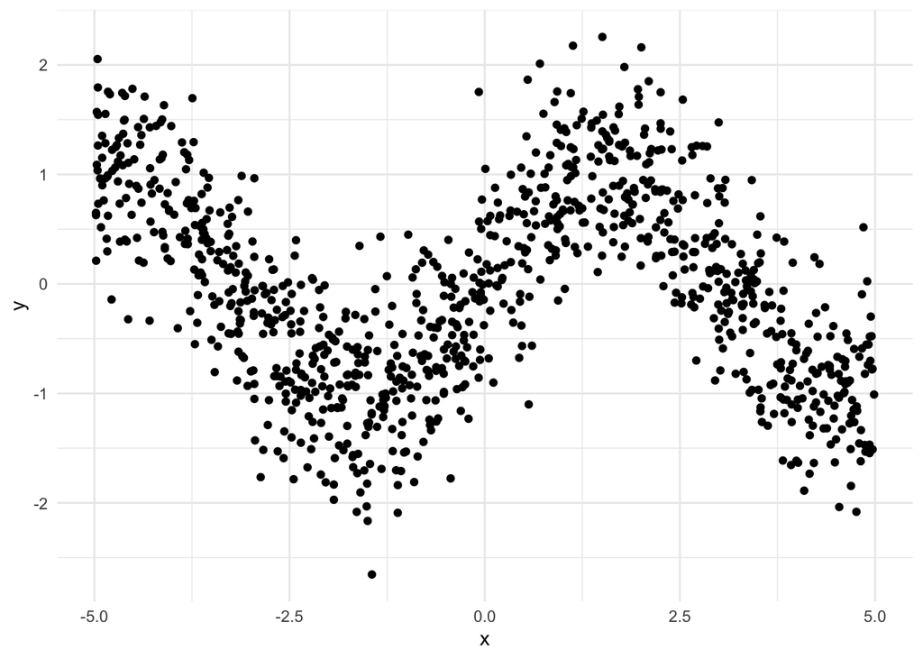

```r
set.seed(1984)
n <- 1000
x <- runif(n, -5,5)
error <- rnorm(n, sd = 0.5)
y <- sin(x) + error
nonlin <- data.frame(y = y, x = x)
train_size <- sample(1:1000, size = 500)
nonlin_train <- nonlin[train_size,]
nonlin_test <- nonlin[-train_size,]
ggplot(nonlin,aes(y=y,x=x))+
  geom_point() +
  theme_minimal()
```

- Fit a regression tree using the training set, plot it

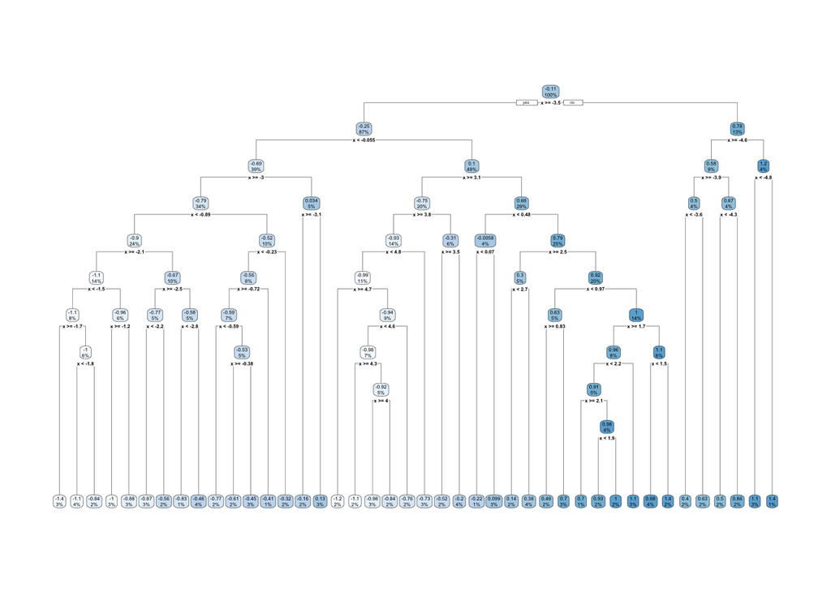

```r
treefit <- rpart(y ~ x, data = nonlin_train, method = "anova", control = list(cp = 0))
rpart.plot(treefit)
```

- Determine the optimal complexity parameter (cp) to prune the tree

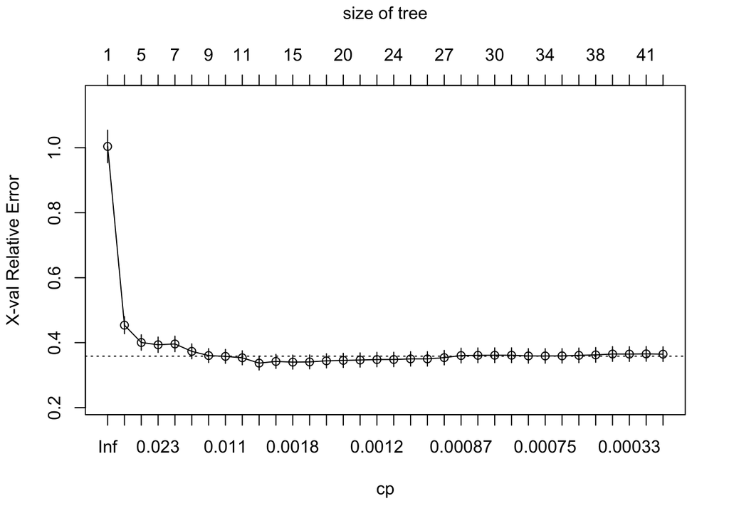

```r
plotcp(treefit)
```

```r
cp_summary <- printcp(treefit)
```

```
##
## Regression tree:
## rpart(formula = y ~ x, data = nonlin_train, method = "anova",
##     control = list(cp = 0))
##
## Variables actually used in tree construction:
## [1] x
##
## Root node error: 419.01/500 = 0.83803
##
## n= 500
##
##            CP nsplit rel error  xerror     xstd
## 1  0.19469747      0   1.00000 1.00402 0.050219
## 2  0.03406113      3   0.41591 0.45381 0.026383
```

[output cut: 32 more lines]

```r
optimal_cp <- cp_summary[9, 1]
```

- Plot the pruned tree and summarize

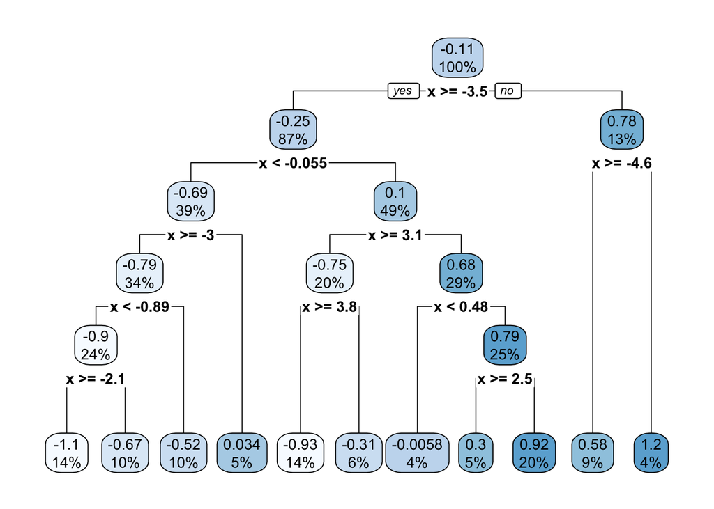

```r
tree_pruned <- prune(treefit, cp = optimal_cp)
rpart.plot(tree_pruned)
```

```r
summary(tree_pruned)
```

```
## Call:
## rpart(formula = y ~ x, data = nonlin_train, method = "anova",
##     control = list(cp = 0))
##   n= 500
##
##            CP nsplit rel error    xerror       xstd
## 1 0.194697471      0 1.0000000 1.0040153 0.05021945
## 2 0.034061135      3 0.4159076 0.4538104 0.02638272
## 3 0.027393414      4 0.3818465 0.4005153 0.02381225
## 4 0.018916616      5 0.3544530 0.3935674 0.02372447
## 5 0.018741339      6 0.3355364 0.3960865 0.02397866
## 6 0.012132319      7 0.3167951 0.3733062 0.02312415
## 7 0.011774257      8 0.3046628 0.3603378 0.02145075
## 8 0.010680660      9 0.2928885 0.3578205 0.02147093
## 9 0.007302594     10 0.2822078 0.3534446 0.02167188
##
## Variable importance
##   x
## 100
##
## Node number 1: 500 observations,    complexity param=0.1946975
##   mean=-0.1147421, MSE=0.8380283
##   left son=2 (436 obs) right son=3 (64 obs)
##   Primary splits:
##       x < -3.484362   to the right, improve=0.1407386, (0 missing)
##
## Node number 2: 436 observations,    complexity param=0.1946975
##   mean=-0.2463199, MSE=0.7852125
##   left son=4 (193 obs) right son=5 (243 obs)
##   Primary splits:
##       x < -0.05508361 to the left,  improve=0.1965717, (0 missing)
##
## Node number 3: 64 observations,    complexity param=0.01213232
##   mean=0.781632, MSE=0.2764066
##   left son=6 (43 obs) right son=7 (21 obs)
##   Primary splits:
##       x < -4.612867   to the right, improve=0.2873718, (0 missing)
##
## Node number 4: 193 observations,    complexity param=0.03406113
##   mean=-0.6871574, MSE=0.3678353
```

[output cut: 57 more lines]

```
##   left son=46 (26 obs) right son=47 (98 obs)
##   Primary splits:
##       x < 2.54086     to the right, improve=0.20428, (0 missing)
##
## Node number 32: 71 observations
##   mean=-1.058638, MSE=0.2497405
##
## Node number 33: 50 observations
##   mean=-0.6680742, MSE=0.2936702
##
## Node number 46: 26 observations
##   mean=0.3027775, MSE=0.233719
##
## Node number 47: 98 observations
##   mean=0.9238571, MSE=0.2530437
```

- Based on the plot and/or summary of the pruned tree create a vector of the (ordered) split points for variable x, and a vector of fitted values for the intervals determined by the split points of x.

```r
x_splits <-  sort(tree_pruned$splits[ , "index"])
# y_frame <- tree_pruned$frame
# y_splits <- y_frame |>
#   filter(var == '<leaf>') |>
#   pull(yval)

predict(tree_pruned, data.frame(x = x_splits))
```

```
##            1            2            3            4            5            6
##  0.584674844  0.034453315 -0.668074168 -1.058637893 -0.518359653 -0.005837036
##            7            8            9           10
##  0.923857058  0.302777531 -0.308884110 -0.929044682
```

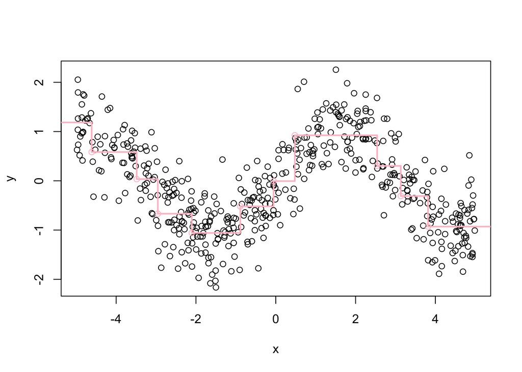

```r
stpfn <- stepfun(x_splits, predict(tree_pruned, data.frame(x = c(-999, x_splits))))
plot(y ~ x, data = nonlin_train)
plot(stpfn, add = TRUE, lwd = 2, col = 'pink')
```

- Fit a linear model to the training data and plot the regression line.

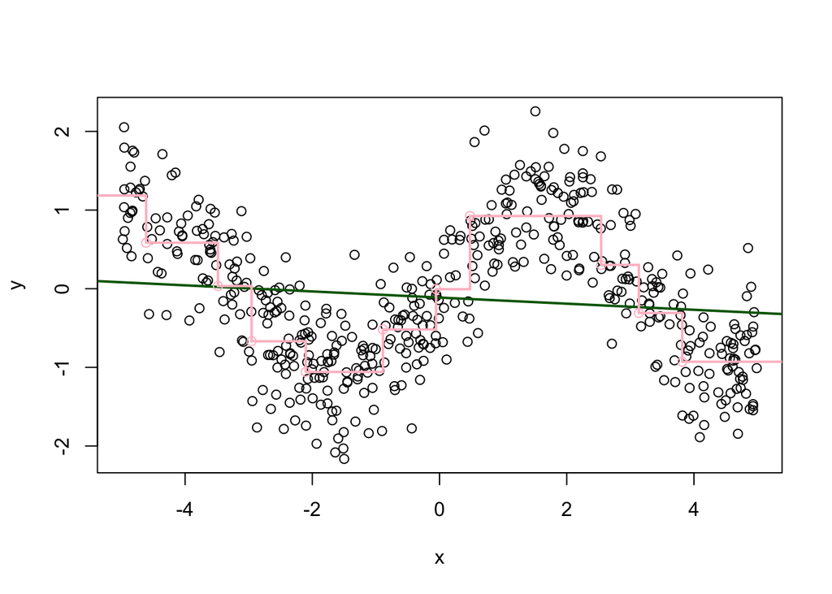

```r
lmfit <- lm(y ~ x, data = nonlin_train)
plot(y ~ x, data = nonlin_train)
abline(lmfit, col = 'darkgreen', lwd = 2)
plot(stpfn, add = TRUE, lwd = 2, col = 'pink')
```

- Contrast the quality of the fit of the tree model vs. linear regression by inspection of the plot

The trend predicted by tree model is more consistent with the real trend than linear regression

```r
tree_pred <- predict(tree_pruned, nonlin_test)
lm_pred <- predict(lmfit, nonlin_test)
tibble(tree_pred, lm_pred, y = nonlin_test$y) |>
  summarise(
    tree_mse =  sum((tree_pred - y)^2) / n(),
    lm_mse = sum((lm_pred - y)^2 / n())
  )
```

```
## # A tibble: 1 × 2
##   tree_mse lm_mse
##      <dbl>  <dbl>
## 1    0.319  0.785
```

- Is the lm or regression tree better at fitting a non-linear function?

tree_mse is much smaller than lm_mse, so tree is better.

## Question 2: Analysis of Real Data

- Split the `heart` data into training and testing (70-30%)

```r
set.seed(2023)
train <- sample(1:nrow(heart), round(0.7*nrow(heart)))
heart_train <- heart[train,]
heart_test <- heart[-train,]
```

- Fit a classification tree using rpart, plot the full tree

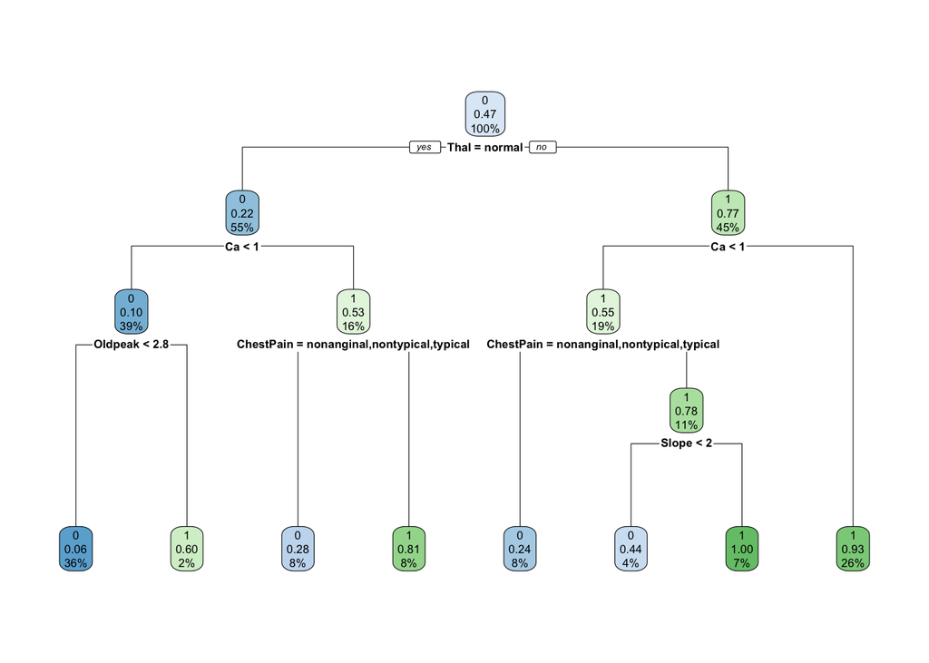

```r
heart_tree <- rpart(
  AHD ~., data = heart_train,
  method = "class",
  control = list(minsplits = 10, minbucket = 3, cp = 0, xval = 10)
)
rpart.plot(heart_tree)
```

- Plot the complexity parameter table for an rpart fit and prune the tree

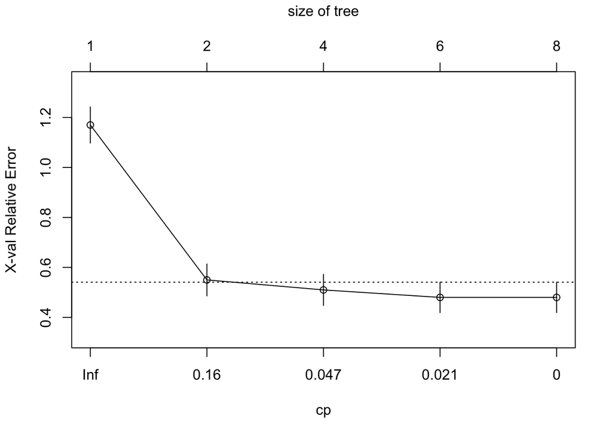

```r
plotcp(heart_tree)
```

```r
cp_summary <- printcp(heart_tree)
```

```
##
## Classification tree:
## rpart(formula = AHD ~ ., data = heart_train, method = "class",
##     control = list(minsplits = 10, minbucket = 3, cp = 0, xval = 10))
##
## Variables actually used in tree construction:
## [1] Ca        ChestPain Oldpeak   Slope     Thal
##
## Root node error: 100/212 = 0.4717
##
## n= 212
##
##      CP nsplit rel error xerror     xstd
## 1 0.520      0      1.00   1.17 0.072408
## 2 0.050      1      0.48   0.55 0.063821
## 3 0.045      3      0.38   0.51 0.062234
## 4 0.010      5      0.29   0.48 0.060936
## 5 0.000      7      0.27   0.48 0.060936
```

```r
optimal_cp <- cp_summary[2, 1]
```

- Compute the test misclassification error
  $$Err = \frac{1}{n}\sum_{i=1}^n I\left(y_i \neq y
  \right)$$

```r
heart_pred <- predict(heart_tree, heart_test)
sum((heart_pred[ , 2] > 0.5) == (heart_test$AHD == 0)) / nrow(heart_test)
```

```
## [1] 0.2197802
```

- Fit the tree with the optimal complexity parameter to the full data (training + testing)

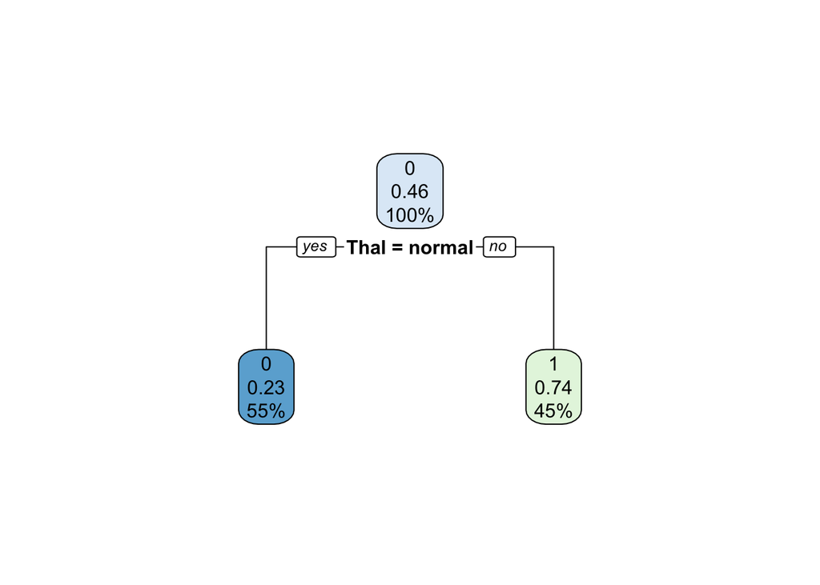

```r
heart_tree_full <- rpart(
  AHD ~., data = heart,
  method = "class",
  control = list(minsplits = 10, minbucket = 3, cp = 0, xval = 10)
)
heart_tree_pruned <- prune(heart_tree_full, cp = optimal_cp)
rpart.plot(heart_tree_pruned)
```

```r
summary(heart_tree_pruned)
```

```
## Call:
## rpart(formula = AHD ~ ., data = heart, method = "class", control = list(minsplits = 10,
##     minbucket = 3, cp = 0, xval = 10))
##   n= 303
##
##          CP nsplit rel error   xerror       xstd
## 1 0.4748201      0 1.0000000 1.000000 0.06240124
## 2 0.0500000      1 0.5251799 0.647482 0.05722357
##
## Variable importance
##      Thal     MaxHR ChestPain     ExAng   Oldpeak       Sex
##        43        13        12        11        11        11
##
## Node number 1: 303 observations,    complexity param=0.4748201
##   predicted class=0  expected loss=0.4587459  P(node) =1
##     class counts:   164   139
##    probabilities: 0.541 0.459
##   left son=2 (167 obs) right son=3 (136 obs)
##   Primary splits:
##       Thal      splits as  RLR,       improve=41.08170, (2 missing)
##       ChestPain splits as  RLLL,      improve=40.13453, (0 missing)
##       Ca        < 0.5   to the left,  improve=34.28686, (4 missing)
##       ExAng     < 0.5   to the left,  improve=28.06728, (0 missing)
##       MaxHR     < 147.5 to the right, improve=25.61790, (0 missing)
##   Surrogate splits:
##       MaxHR     < 150.5 to the right, agree=0.684, adj=0.296, (2 split)
##       ChestPain splits as  RLLL,      agree=0.674, adj=0.274, (0 split)
##       ExAng     < 0.5   to the left,  agree=0.671, adj=0.267, (0 split)
##       Sex       < 0.5   to the left,  agree=0.661, adj=0.244, (0 split)
##       Oldpeak   < 1.55  to the left,  agree=0.661, adj=0.244, (0 split)
##
## Node number 2: 167 observations
##   predicted class=0  expected loss=0.2275449  P(node) =0.5511551
##     class counts:   129    38
##    probabilities: 0.772 0.228
##
## Node number 3: 136 observations
##   predicted class=1  expected loss=0.2573529  P(node) =0.4488449
##     class counts:    35   101
##    probabilities: 0.257 0.743
```

## Question 3: Bagging, Random Forest

- Compare the performance of classification trees (above), bagging, random forests for predicting heart disease based on the `heart` data.
- Split the data into training and testing. Train each of the models on the training data and extract the cross-validation (or out-of-bag error for bagging and Random forest).

```r
set.seed(2023)
train <- sample(1:nrow(heart), round(0.7 * nrow(heart)))
heart_train <- heart[train, ]
heart_test <- heart[-train, ]
```

- For bagging use `randomForest` with `mtry` equal to the number of features (all other parameters at their default values). Generate the variable importance plot using `varImpPlot` and extract variable importance from the `randomForest` fitted object using the `importance` function.

```r
n_features <- dim(heart_train)[2] - 1
heart_bagging <- randomForest(as.factor(AHD) ~ ., data = heart_train, mtry = n_features, na.action = na.omit)
mean(heart_bagging$err.rate[, 1])
```

```
## [1] 0.1988715
```

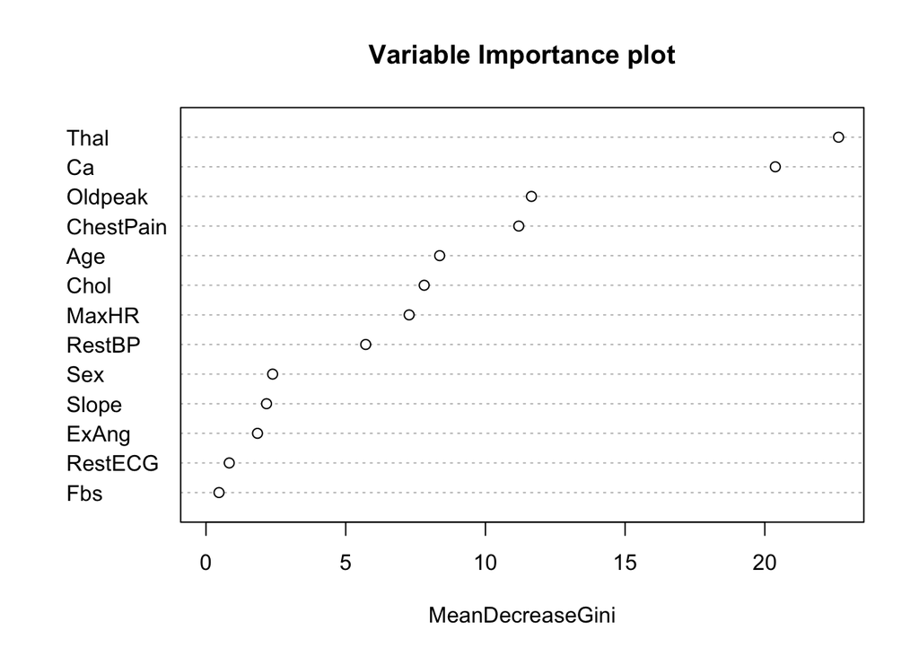

```r
varImpPlot(heart_bagging, main = "Variable Importance plot")
```

```r
importance(heart_bagging)
```

```
##           MeanDecreaseGini
## Age               8.362488
## Sex               2.384178
## ChestPain        11.193739
## RestBP            5.715497
## Chol              7.809232
## Fbs               0.465132
## RestECG           0.831931
## MaxHR             7.270801
## ExAng             1.842506
## Oldpeak          11.647248
## Slope             2.165638
## Ca               20.376476
## Thal             22.639638
```

- For random forests use `randomForest` with the default parameters. Generate the variable importance plot using `varImpPlot` and extract variable importance from the `randomForest` fitted object using the `importance` function.

```r
floor(sqrt(n_features))
```

```
## [1] 3
```

```r
heart_forest <- randomForest(as.factor(AHD) ~ .,
                             data = heart_train,
                             na.action = na.omit)

mean(heart_forest$err.rate[, 1])
```

```
## [1] 0.1734378
```

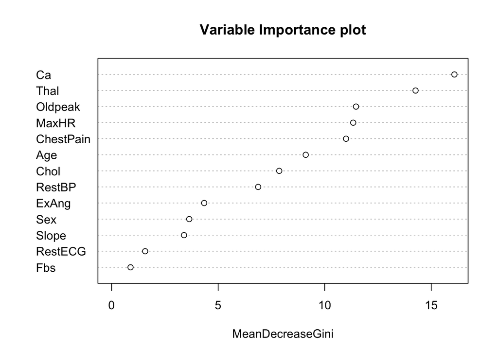

```r
varImpPlot(heart_forest, main = "Variable Importance plot")
```

```r
importance(heart_forest)
```

```
##           MeanDecreaseGini
## Age              9.1088001
## Sex              3.6416675
## ChestPain       11.0015016
## RestBP           6.8759318
## Chol             7.8650807
## Fbs              0.8872265
## RestECG          1.5733708
## MaxHR           11.3375037
## ExAng            4.3428258
## Oldpeak         11.4690242
## Slope            3.3970545
## Ca              16.0871434
## Thal            14.2631417
```

## Question 4: Boosting

- For boosting use `gbm` with `cv.folds=5` to perform 5-fold cross-validation, and set `class.stratify.cv` to `AHD` (heart disease outcome) so that cross-validation is performed stratifying by `AHD`. Plot the cross-validation error as a function of the boosting iteration/trees (the `$cv.error` component of the object returned by `gbm`) and determine whether additional boosting iterations are warranted. If so, run additional iterations with `gbm.more` (use the R help to check its syntax). Choose the optimal number of iterations. Use the `summary.gbm` function to generate the variable importance plot and extract variable importance/influence (`summary.gbm` does both). Generate 1D and 2D marginal plots with `gbm.plot` to assess the effect of the top three variables and their 2-way interactions.

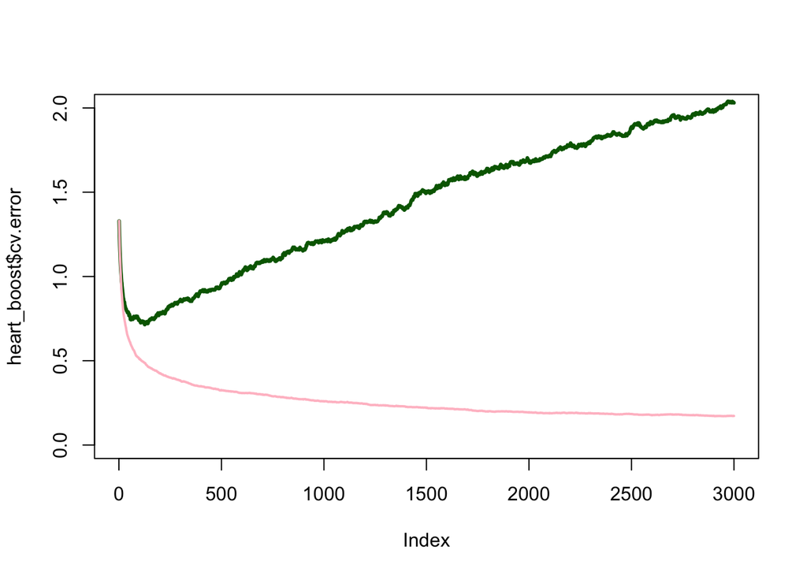

```r
heart_boost <- gbm(
  AHD ~. , data = heart_train,
  distribution = "bernoulli",
  cv.folds = 5, class.stratify.cv = TRUE,
  n.trees = 3000
)
plot(heart_boost$cv.error, type = 'l', ylim = c(0, 2), lwd = 3, col = "darkgreen")
lines(heart_boost$train.error, lwd = 2, col = "pink")
```

# Deliverables

1. Questions 1-4 answered, pdf or html output uploaded to quercus